# Exercise 3 of “Big Data Analytics” (Winter Semester 2020/21)

# Task 3: Classifier Evaluation

First, we pre-load some packages we will use in multiple sub-tasks:

```r
library(data.table)
library(ggplot2)
library(rpart)
```

Second, we prepare a version of the `iris` dataset with binary target variable:

```r
dataset <- iris[, colnames(iris) != "Species"]
dataset$virginica <- factor(c("no", "yes")[(iris$Species == "virginica") + 1])
```

The definition of the target variable might be confusing at first sight. We first create a Boolean vector by checking the species’ name. This can also be seen as a vector of zeros and ones, so we can add 1 to get a vector of ones and twos. With that, we select from “no” and “yes”. So you see that it is possible to query multiple, even duplicated, indices from a vector.

To make our code more generic, we define a variable for the prediction target. This allows swapping the dataset if we wanted.

```r
target <- "virginica"
predictionFormula <- as.formula(paste(target, "~ ."))
```

### a) Baselines (1) - Predict Majority

While the original dataset was balanced between species, the new one is slightly imbalanced:

```r
table(dataset[[target]])
```

```
 no yes
100  50
```

Due to the imbalance, guessing the majority class yields an accuracy higher than zero. If the dataset was more imbalanced, we would have the change the evaluation metric altogether.

```r
prediction <- rep(names(which.max(table(dataset[[target]]))), times = nrow(dataset))
cat("Accuracy:", sum(prediction == dataset[[target]]) / nrow(dataset))
```

```
Accuracy: 0.6666667
```

(The code is more complicated than it needs to be, but the aim is to create a prediction vector which is consistent with the output of real models.) Any proper prediction model should beat that baseline accuracy. If a prediction model is significantly worse, something might be wrong with its configuration (e.g., data format). Note that we don’t do a train-test split here for simplicity reasons. However, if classes are imbalanced, splits should be stratified anyway, which means that the proportion of class labels is the same in train and test.

### b) Baselines (2) - One Rules

While guessing the majority class already tells us something about the target variable, it does not use any features. By using One Rules, we at least learn which feature is considered best by that model:

```r
library(OneR)
oneRulesModel <- OneR(formula = predictionFormula, data = dataset)
summary(oneRulesModel)
```

```
Call:
OneR.formula(formula = predictionFormula, data = dataset)

Rules:
If Petal.Width = (0.0976,0.58] then virginica = no
If Petal.Width = (0.58,1.06]   then virginica = no
If Petal.Width = (1.06,1.54]   then virginica = no
If Petal.Width = (1.54,2.02]   then virginica = yes
If Petal.Width = (2.02,2.5]    then virginica = yes

Accuracy:
142 of 150 instances classified correctly (94.67%)

Contingency table:
         Petal.Width
virginica (0.0976,0.58] (0.58,1.06] (1.06,1.54] (1.54,2.02] (2.02,2.5] Sum
      no           * 49         * 8        * 38           5          0 100
      yes             0           0           3        * 24       * 23  50
      Sum            49           8          41          29         23 150
---
Maximum in each column: '*'

Pearson's Chi-squared test:
X-squared = 118.87, df = 4, p-value < 2.2e-16
```

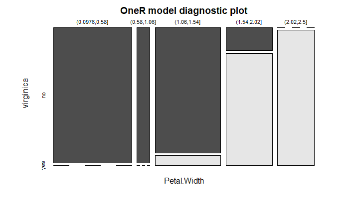

```r
plot(oneRulesModel)
```

```r
prediction <- predict(oneRulesModel, newdata = dataset)
cat("Accuracy:", sum(prediction == dataset[[target]]) / nrow(dataset))
```

```
Accuracy: 0.9466667
```

According to `help(OneR)`, the given implementation of One Rules performs equal-width binning of numeric features by default. As we know from previous tasks, for this simple dataset, there is a good separability of classes by using individual features. However, one still needs to determine a good split point. From that perspective, equal-width binning generally seems not optimal. The accuracy is quite good in our case, though, as the bin border falls close to a good split point by chance. You could also do the binning on your own, for example based on entropy. However, in that case, you could also simply learn a decision tree with just one split (“decision stump”).

### c) Holdout splits

To test different train-test splits, we simply loop over them and combine the results in a table:

```r
set.seed(25)
trainFractions <- seq(from = 0.1, to = 0.9, by = 0.05)
resultsTable <- rbindlist(lapply(trainFractions, function(trainFraction) {
  trainIdxPerClass <- lapply(unique(dataset[[target]]), function(classLab) {
    classIdx <- which(dataset[[target]] == classLab)
    sample(classIdx, size = round(trainFraction * length(classIdx)), replace = FALSE)
  })
  trainIdx <- sort(unlist(trainIdxPerClass))
  testIdx <- c(1:nrow(dataset))[-trainIdx] # use all indices except trainIdx
  trainData <- dataset[trainIdx, ]
  testData <- dataset[testIdx, ]
  model <- rpart(predictionFormula, data = trainData)
  trainPrediction <- predict(model, newdata = trainData, type = "class")
  testPrediction <- predict(model, newdata = testData, type = "class")
  trainAcc <- sum(trainPrediction == trainData[[target]]) / length(trainPrediction)
  testAcc <- sum(testPrediction == testData[[target]]) / length(testPrediction)
  return(list(TrainFraction = trainFraction, Train = trainAcc, Test = testAcc))
}))
```

`lapply` is our loop over the different split ratios. `rbindlist` from the `data.table` package allows to combine a list of lists (with same components) to a table. To get a stratified split, we sample the same fraction of train objects from each class independently and combine the results. The rest of the code is quite similar to the task on decision trees. Now let’s plot this:

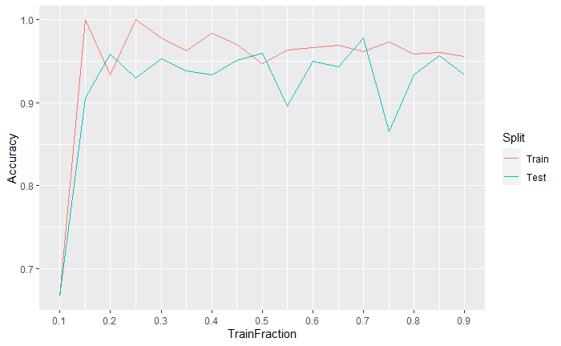

```r
plotData <- reshape2::melt(resultsTable, id.vars = "TrainFraction",
                           variable.name = "Split", value.name = "Accuracy")
ggplot(data = plotData) +
  geom_line(mapping = aes(x = TrainFraction, y = Accuracy, color = Split)) +
  scale_x_continuous(breaks = seq(from = 0, to = 1, by = 0.1))
```

Generally, we expect a model trained with more data (from the same distribution) to make better predictions. At the same time, reducing the size of the test set could make performance evaluation slightly unstable. As mentioned before, the `iris` data are rather simple to classify. Thus, we should not be too surprised to see not much of the expected effects. Only with very small training sets, the prediction quality deteriorates.

Though manually creating a split is quite easy, there are also functions for that. For example, the `caret` package contains the function `createDataPartition()`. `caret` even allows to directly train a huge variety of models with cross-validation, optimize hyper-parameters, store and plot results etc. However, this is not the topic of this exercise ;-)

### d) Cross-validation

```r
set.seed(25)
kValues <- 2:20
resultsTable <- rbindlist(lapply(kValues, function(k) {
  folds <- rep(0, times = nrow(dataset))
  for (classLab in unique(dataset[[target]])) {
    classIdx <- which(dataset[[target]] == classLab)
    folds[classIdx] <- sample(rep(1:k, length.out = length(classIdx)), replace = FALSE)
  }
  trainPerformances <- rep(0, times = k)
  testPerformances <- rep(0, times = k)
  for (i in 1:k) {
    trainData <- dataset[folds != i, ]
    testData <- dataset[folds == i, ]
    model <- rpart(predictionFormula, data = trainData)
    trainPrediction <- predict(model, newdata = trainData, type = "class")
    testPrediction <- predict(model, newdata = testData, type = "class")
    trainPerformances[i] <- sum(trainPrediction == trainData[[target]]) / length(trainPrediction)
    testPerformances[i] <- sum(testPrediction == testData[[target]]) / length(testPrediction)
  }
  return(list(k = k, TrainMean = mean(trainPerformances), TrainSd = sd(trainPerformances),
              TestMean = mean(testPerformances), TestSd = sd(testPerformances)))
}))
```

Determining which data objects goes into which fold is slightly complicated. To get a stratified assignment, we repeat the following procedure for each class: We create a vector consisting of the values 1 to k in equal proportion (as far as possible, considering divisibility) with `rep()`. We bring this vector into random order by applying `sample()` without specifying a `size`. We store the result in one vector describing the fold assignment for all data objects, independent from the class. As an alternative, with some more effort, we could create a list of train-splits. By the way, you could also use `createFolds()` from `caret` for splitting.

For each value of k, we then need to loop over all train-test splits based on the folds. Training and prediction remains the same. As the number of folds varies between the iterations of the outer loop (loop over k), we store mean and standard deviation of train/test performance for each k. Now let’s plot this:

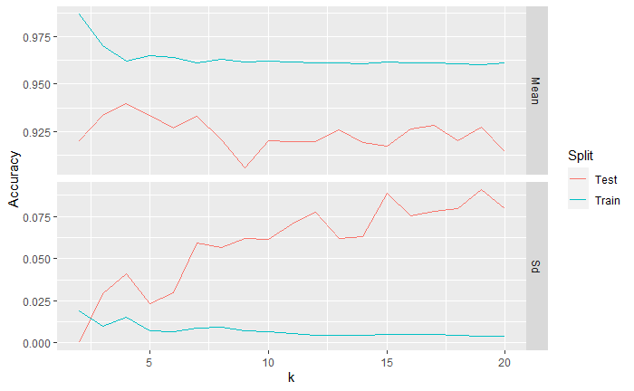

```r
plotData <- reshape2::melt(resultsTable, id.vars = "k", value.name = "Accuracy")
plotData$Split <- sub(pattern = "Mean|Sd", replacement = "", x = plotData$variable)
plotData$Statistic <- sub(pattern = "Train|Test", replacement = "", x = plotData$variable)
plotData$variable <- NULL
ggplot(data = plotData) +
  geom_line(mapping = aes(x = k, y = Accuracy, color = Split)) +
  facet_grid(Statistic ~ ., scales = "free")
```

Again, we need to do some reshaping before plotting. We use string substitution with very simple regular expressions to get separate columns to identify split and statistic.

In the plots, the standard deviation over folds slightly increases for the test splits, and even more slightly decreases for the train splits. This makes sense: With growing k, the train split of the dataset becomes bigger, though it already was quite from the start (at least 50%). In contrast, the test split gets smaller, down to 5% for 20-fold CV. With such small test sets, we expect a higher impact of random fluctuation and thus more volatility in single evaluations. However, higher k also mean that we average over more folds at the end, which stabilizes the estimate of accuracy.

In our plots, there also is no trend of mean accuracy over the values of k. One could expect an increase with k, as more and more data is used for training. However, as we said before, the dataset is quite easy to classify.

Thus, there is no generally best value of k. Using five-fold CV usually is equally valid as using leave-one-out CV, where each test split consists only of one data object. Of course, the higher k, the more expensive the evaluation becomes. Thus, 5 and 10 are typical values for k. [Here](https://stats.stackexchange.com/questions/154830/10-fold-cross-validation-vs-leave-one-out-cross-validation) and [here](https://stats.stackexchange.com/questions/61783/bias-and-variance-in-leave-one-out-vs-k-fold-cross-validation/244112) are two interesting StackExchange posts discussing the choice of k.

### e) Regularization

To learn trees of different complexity, we control the minimum number of data objects required to potentially split a node (`minsplit`). Some other options to control complexity are the minimum number of data objects in leaves (`minbucket`), maximum tree height (`maxdepth`) or minimum improvement required by splits (`cp`). As these different options might interact, we only vary one of them in the following. We use 10-fold cross-validation for evaluation.

```r
set.seed(25)
k = 10
minSplits <- seq(from = 0, to = 100, by = 5)
resultsTable <- rbindlist(lapply(minSplits, function(minSplit) {
  folds <- rep(0, times = nrow(dataset))
  for (classLab in unique(dataset[[target]])) {
    classIdx <- which(dataset[[target]] == classLab)
    folds[classIdx] <- sample(rep(1:k, length.out = length(classIdx)), replace = FALSE)
  }
  trainPerformances <- rep(0, times = k)
  testPerformances <- rep(0, times = k)
  for (i in 1:k) {
    trainData <- dataset[folds != i, ]
    testData <- dataset[folds == i, ]
    model <- rpart(predictionFormula, data = trainData, control = rpart.control(
      minsplit = minSplit, minbucket = 0, cp = 0))
    trainPrediction <- predict(model, newdata = trainData, type = "class")
    testPrediction <- predict(model, newdata = testData, type = "class")
    trainPerformances[i] <- sum(trainPrediction == trainData[[target]]) / length(trainPrediction)
    testPerformances[i] <- sum(testPrediction == testData[[target]]) / length(testPrediction)
  }
  return(list(MinSplit = minSplit, Train = mean(trainPerformances), Test = mean(testPerformances)))
}))
```

The code is very similar to the last sub-task, where we iterated over values of `k`. This time, we fix `k` to ten and iterate over `minSplits`. Also, note we adjust the training of decision trees with the `control` parameter.

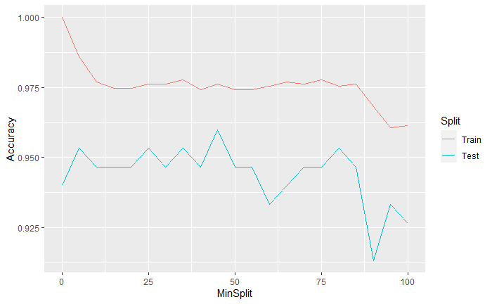

```r
plotData <- reshape2::melt(resultsTable, id.vars = "MinSplit", variable.name = "Split",
                           value.name = "Accuracy")
ggplot(data = plotData) +
  geom_line(mapping = aes(x = MinSplit, y = Accuracy, color = Split))
```

By requiring a very small number of data object per node, we can easily improve train accuracy. This generally (and also in our case) increases the difference between train and test performance, i.e., overfitting occurs. Learning less complex trees could improve generalization, but could also make the model too simple to describe the data. In practice, one would usually do a systematic search over the hyper-parameters of the model. We kind of do this here, though just for one hyper-parameter. In our case, there is no clear trend regarding test performance. The least complex trees (i.e., with the biggest minimum node size) seem to loose some prediction performance.

### f) ROC Curve

Back to a simple train-test split, as we want to show just one curve:

```r
set.seed(25)
trainIdx <- sort(sample(1:nrow(dataset), size = round(0.7 * nrow(dataset)), replace = FALSE))
testIdx <- c(1:nrow(dataset))[-trainIdx] # use all indices except trainIdx
trainData <- dataset[trainIdx, ]
testData <- dataset[testIdx, ]
model <- rpart(predictionFormula, data = trainData, control = rpart.control(minsplit = 10))
testPrediction <- predict(model, newdata = testData, type = "prob")
str(testPrediction)
```

```
 num [1:45, 1:2] 1 1 1 1 1 1 1 1 1 1 ...
 - attr(*, "dimnames")=List of 2
  ..$ : chr [1:45] "1" "6" "10" "11" ...
  ..$ : chr [1:2] "no" "yes"
```

As you might have noted, we again set `minsplit`. We do this to increase the number of nodes in the tree, so the ROC curve gets some more points where it changes its gradient.

When predicting probabilities for `rpart`, we get a matrix with probabilities for each class. For creating a ROC curve, we need to decide what the “positive” class is, since the curve is based on true-positive rate and false-positive rate. We choose the class `yes` (i.e., object belongs to species “virginica”) as positive.

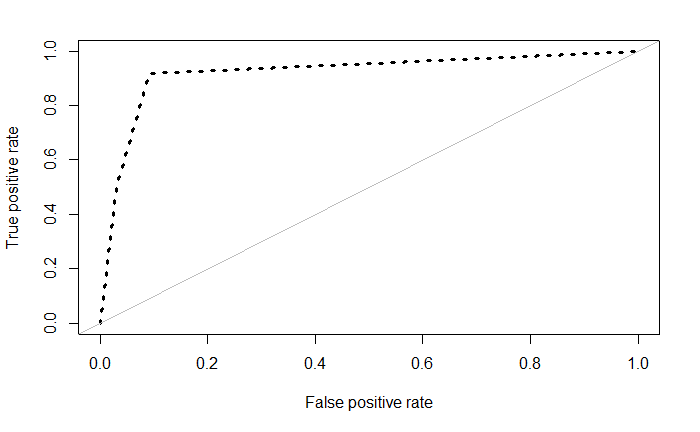

```r
library(ROCR)
rocrPredObject <- prediction(predictions = testPrediction[, 2],
    labels = testData[[target]], label.ordering = levels(testData[[target]]))
rocrPerfObject <- performance(rocrPredObject,"tpr","fpr") # ROC curve
plot(rocrPerfObject, col = "black", lty = 3, lwd = 3, las = 1)
abline(0, 1, col = "gray")
```

The `ROCR` package also allows the creation of other curves, e.g., precision-recall curves. You can just pass different performance metrics to be computed.

Computing the AUC also is possible:

```r
performance(rocrPredObject, measure = "auc")@y.values
```

```
[[1]]
[1] 0.9217172
```

Note the `@` notation. This is because the object storing the performance is an S4 object. In the previous exercises, if an object was returned, it usually belonged to the older S3 object system. With S3 objects, you access attributes with the list-like `$` notation.

Note that you need to be careful when determining the positive class. If you pass predictions for the wrong class, your plot might look like this:

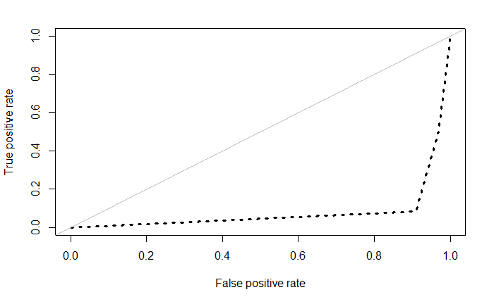

```r
library(ROCR)
rocrPredObject <- prediction(predictions = testPrediction[, 1],
    labels = testData[[target]], label.ordering = levels(testData[[target]]))
rocrPerfObject <- performance(rocrPredObject,"tpr","fpr") # ROC curve
plot(rocrPerfObject, col = "black", lty = 3, lwd = 3, las = 1)
abline(0, 1, col = "gray")
```

Functionality for `ROC` curves also is part of many other packages, e.g., `ROSE`, `precrec`, `pROC`. `ROSE` is easier to use than `ROCR`:

```
Area under the curve (AUC): 0.922
```

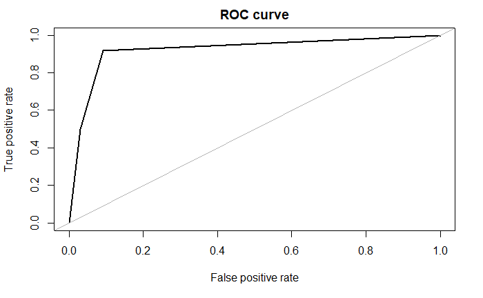

```r
library(ROSE)
roc.curve(response = testData[[target]], predicted = testPrediction[, 2])
```

Also, if you pass predictions for the wrong class, they automatically are inverted. (Which can also be seen as negative, because it hides programming errors.)

Finally, how do you actually calculate a ROC curve? First, you need to order the predicted class probabilities decreasingly. Next, for each distinct value from this list, you create a discrete prediction. This means you predict “positive” for all data objects which have at least that probability, and “negative” for the rest. With that, you can compute true-positive rate and false-positive rate.

```r
ordIdx <- order(testPrediction[, 2], decreasing = TRUE)
sortedPreds <- data.frame(Prediction = testPrediction[ordIdx, 2],
                          Target = testData[[target]][ordIdx])
negative <- levels(testData[[target]])[1]
positive <- levels(testData[[target]])[2]
roc.curve(response = testData[[target]], predicted = testPrediction[, 2])
```

```
Area under the curve (AUC): 0.922
```

```
Threshold of 1 with a TPR of 0.5 and FPR 0.03
Threshold of 0.6 with a TPR of 0.92 and FPR 0.09
Threshold of 0 with a TPR of 1 and FPR 1
```

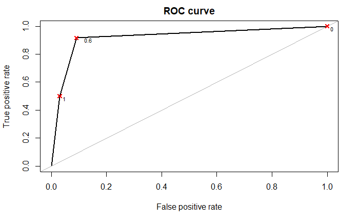

```r
for (threshold in unique(sortedPreds$Prediction)) {
  curPreds <- sortedPreds$Target[sortedPreds$Prediction >= threshold]
  tpr <- sum(curPreds == positive) / sum(sortedPreds$Target == positive) # true positive rate
  fpr <- sum(curPreds == negative) / sum(sortedPreds$Target == negative) # false positive rate
  points(x = fpr, y = tpr, pch = 4, lwd = 2, col = "red") # mark on (existing ROC) plot
  text(x = fpr, y = tpr, labels = round(threshold, 4), cex = 0.7, adj = c(-1, 1))
  cat(paste0("Threshold of ", round(threshold, 4), " with a TPR of ",
             round(tpr, 2), " and FPR ", round(fpr, 2), "\n"))
}
```

Note that in standard R plotting, you can easily add further elements to the last plot. Here, we call `points()` to mark the points at the end of the line segments.

We can see that the curve is rather close to the top-left corner, which means that prediction quality is high. To be more specific: Consider the objects for which we have predicted a high probability of belonging to the positive class. Among these objects, there are many true positives, but only a few false positives. Thus, we mainly move in the upwards direction and only slightly to the right. With each step of the curve, we lower the prediction threshold. This means a higher fraction of actually positive objects are predicted as positive – the true-positive rate, i.e., recall increases. At the same time, a higher fraction of actually negative objects are also predicted as positive – the false-positive rate increases.